# Introduccion a R. Segunda Parte

Ivone Humacata

2023-10-08

# Sección 0: Introducción

Durante el transcurso de su trabajo, se le ocurren preguntas de investigación interesantes, discute formas de recopilar datos con sus colaboradores para responder su pregunta y desea utilizar números y gráficos para comunicar sus resultados y simplificar ideas complejas. Ahora quizás te preguntes:¿cómo realmente hago esto yo mismo? Cuando recopilo información, ¿cómo trabajo con ella para darle sentido a las cosas y cómo puedo producir imágenes para comunicar mis resultados a los demás? Puedes hacer esto con programación y visualización de datos. Un lenguaje de programación común que usaremos se llama R.

Al finalizar este taller, podrá:

- Importar un conjunto de datos de COVID-19
- Comprender los principios de la visualización de datos.
- ¡Y tener los recursos y herramientas para realizar su propia visualización de datos más adelante!

## Qué es R? ¿Qué puede hacer?

R es un lenguaje de programación diseñado para computación estadística. Como cualquier otro lenguaje, tiene un conjunto particular de reglas, palabras y símbolos que podemos usar para escribir instrucciones que nuestra computadora entenderá. Hay muchas cosas especiales sobre el lenguaje R enparticular, incluyendo amplias capacidades, amplia gama de técnicas estadísticas y gráficas. Es GRATIS (sin costo, ``código abierto’’). Excelente soporte comunitario: lista de correo, blogs, tutoriales. Fácil de ampliar escribiendo nuevas funciones. Incluso puedes usar R desde la nube: https://login.rstudio.cloud/

## ¿Cómo usar R y empezar a codificar? ¿Qué es RStudio?

RStudio es un entorno de desarrollo integrado (IDE) que utilizamos para escribir código en R. Es una interfaz de visual. Si R es el idioma, RStudio es como la aplicación de mensajería que usamos para enviar instrucciones a la computadora escritas en ese idioma y recibir los resultados. RStudio nos muestra nuestro código, resultados y gráficos. También facilita la obtención de información de ayuda sobre cómo usar R. Comencemos mirando las cuatro partes de la interfaz RStudio.

- Arriba a la izquierda: este es el editor. Es donde escribes y guardas tu código. Si resalta una porción del código y presiona Control + Enter entonces el código resaltado se ejecutará.
- Abajo a la izquierda: esta es la consola. Le muestra el código que acaba de ejecutar y cuál es el resultado.
- Arriba a la derecha: este es el medio ambiente. Si crea o almacena algún objeto en su código, aparecerá aquí. El historial contiene todos los comandos que envió a la consola.
- Abajo a la derecha: esta es la ventana de gráficos (Plots). Si crea gráficos, aparecen aquí. También es donde aparece la información de ayuda (Help). Files (Archivos) muestra el directorio donde R cree que está su espacio de trabajo y Help (Ayuda) le muestra los archivos de ayuda y la documentación.

[figure not shown]

## ¿Cómo escribo y ejecuto código?

Abra RStudio y cree un nuevo ‘script’ yendo a File > New file > R Script. Esto abrirá lo que parece un documento en blanco en la parte superior izquierda de la pantalla de RStudio.

R scripts son sólo archivos de texto que almacenan su código. Cuando los guardes, obtendrán una extensión .R, que le permite a su computadora saber que debe abrirlo con R.

Lo llamamos “script” (guión es español) porque, como el guión de una obra de teatro, este archivo se convertirá en un conjunto de “instrucciones” que le das a la computadora para decirle qué hacer. Es mejor escribir y ejecutar código desde un script en el editor, para poder realizar un seguimiento de lo que has hecho.

Escriba el siguiente encabezado a continuación en el nuevo script y luego guárdelo en su directorio.

```r
#--INTRODUCCION A R. SEGUNDA PARTE
#-- Aqui deben colocar su nombre
#-- Aqui deben colocar la fecha
```

Tenga en cuenta que escribir el símbolo de hashtag cambia el color del texto. Esto convierte la línea en una comentario, por lo que no se ejecutará como otro código. Usamos comentarios para organizar y escribir notas útiles para nuestro código (y despues acordarnos lo que hicimos).

Debajo del encabezado, escriba 2+2, resáltelo y presione Ctrl + Enter. Esto ejecuta el código y deberías ver el resultado en la consola. Puedes hacer más cálculos como los siguientes:

```r
2+3*4
```

```
## [1] 14
```

```r
2+(3*4)
```

```
## [1] 14
```

```r
(2+3)*4
```

```
## [1] 20
```

```r
(15/3)*5-2
```

```
## [1] 23
```

# Sección 1: Variables y Asignación

Como acabamos de ver, R tiene las capacidades de una calculadora: +, -, * y / son símbolos utilizados para la suma, resta, multiplicación y división, respectivamente.

¿Qué sucede si desea almacenar los resultados de un cálculo y utilizarlos en otro cálculo? Para eso creamos lo que se llama variables usando cualquiera de los dos <- o =.

```r
#-- asignar un numero
x <- 5
y <- 3
```

Deberías notar inmediatamente que en el panel superior derecho, la variable x

ha sido almacenado en su entorno y tiene el valor 5, y y ha sido almacenado con el valor 3. Utilice este panel para realizar un seguimiento de las variables que ha creado.

Ahora puede utilizar el valor almacenado para realizar cálculos adicionales. Probemos algunos.

```r
#-- operar las variables
x+y
```

```
## [1] 8
```

```r
x-y
```

```
## [1] 2
```

```r
x*y
```

```
## [1] 15
```

```r
x/y
```

```
## [1] 1.666667
```

```r
x
```

```
## [1] 5
```

```r
y
```

```
## [1] 3
```

Observe que ninguno de estos cálculos cambió el valor de x o y porque no le reasignamos un valor. x todavía es 5, y y sigue siendo 3.

Sin embargo, si reasignamos un valor diferente a x o y, el valor anterior se olvida y se reemplaza por el nuevo valor. ¡Es importante realizar un seguimiento de los cambios que realiza en las variables!

```r
#--reasignar valores
x <- x+4
x
```

```
## [1] 9
```

```r
x+y
```

```
## [1] 12
```

```r
y <- 8
x+y
```

```
## [1] 17
```

Además de los números, R también puede trabajar y almacenar letras y otros caracteres. Los llamamos cadena de caracteres, y pueden ser una amplia gama de valores, como palabras, nombres, oraciones, párrafos, contraseñas, etc. Hacemos esto poniendo la cadena que queremos almacenar entre comillas:

```r
#--almacenar letras
z <- "estamos en el curso de intro a R. Segunda parte"
z
```

```
## [1] "estamos en el curso de intro a R. Segunda parte"
```

```r
#--nombrar las variables
ubicacion <- "Jujuy"
ubicacion
```

```
## [1] "Jujuy"
```

# Sección 2: Instalación de nuevos paquetes

Uno de los beneficios de R es que usuarios de todo el mundo escriben y publican nuevas funciones para que las utilicemos. Los usamos descargando y cargando paquetes de nuevas funciones.

Usar un nuevo paquete requiere dos pasos:

1. Instale el paquete usando install.packages(“nombre del paquete”). Sólo necesita hacer esto la primera vez que utilice un paquete nuevo.
2. Cargue el paquete usando library(nombre del paquete). Debe hacer esto cada vez que cierre y vuelva a abrir RStudio. Puede cargar el paquete sólo después de haberlo instalado.
3. Debe instalar los siguientes paquetes:

```r
#-- instalar paquetes
#install.packages("ggplot2") paquete mas popular para la creacion de graficos
#install.packages("dplyr") utilizado para la manipulacion y transformacion de datos: seleccionar, filtrar, agrupar
#install.packages("tidyverse") incluye ggplot y dplyr entre otros
#install.packages("dslabs") contiene datos para enseñar estadistica y ciencia de datos
#install.packages("gapminder") conjunto de datos sobre indicadores de desarrollo global
#install.packages("ggrepel") complemento de ggplot2 para que las etiquetas no se superpongan
#install.packages("gridExtra") organizar y personalizar graficos en una sola disposicion
#install.packages("RColorBrewer") paleta de colores predefinidas
#install.packages("rnaturalearth") datos geospaciales
#install.packages("rnaturalearthdata") datos geospaciales
#install.packages("sf") simple features manipulacion de datos espaciales
```

Por ejemplo, carguemos un nuevo paquete para ayudar con los gráficos, llamado ggplot2.

```r
#--instalar librerias
library(ggplot2)
# ?ggplot # para ver el archivo de ayuda, hacer clic en index
```

A continuación, utilice ?g gplot para abrir el archivo de ayuda de este paquete y haga clic en el enlace que dice “Index” en la parte inferior para buscar todas las funciones contenidas en el nuevo paquete.

Por ejemplo, ggplot2 tiene una función para un gráfico rápido:

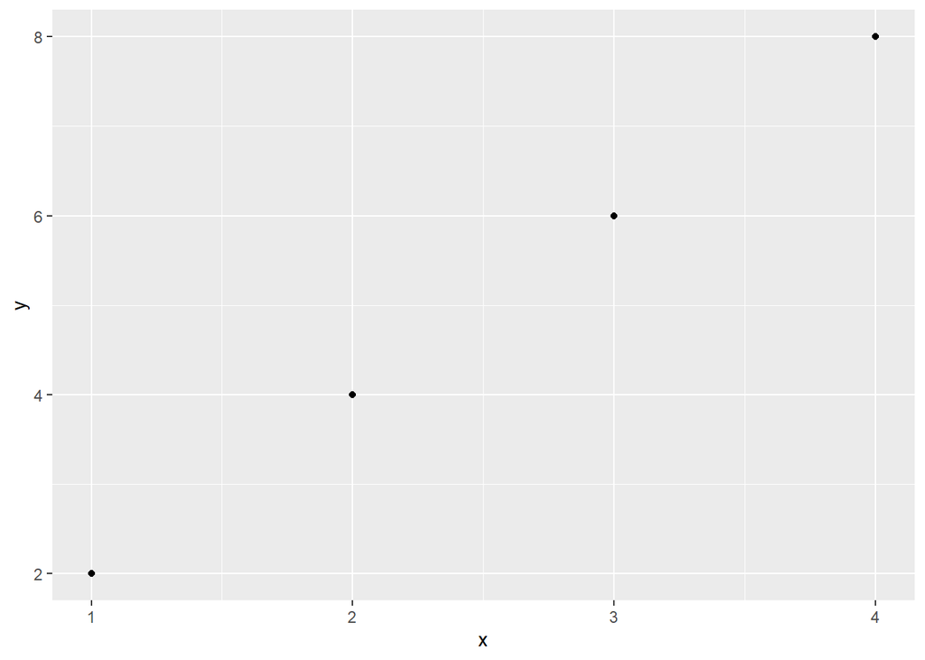

```r
#--grafico de ggplot
x <- c(1, 2, 3, 4)
y <- c(2, 4, 6, 8)
qplot(x, y)
```

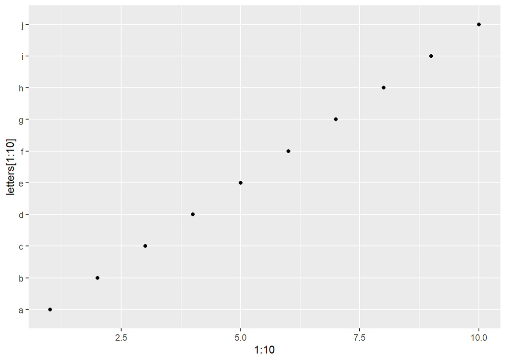

```r
qplot(1:10, letters[1:10])
```

Algunos paquetes incluyen conjuntos de datos. Por ejemplo, el dslabs. El paquete contiene conjuntos de datos que usaremos para la visualización de datos.

```r
#--utilizaremos datos de la libreria dslabs del paquete dslabs
library(dslabs)
data(gapminder) # cargar el conjunto de datos especificado
head(gapminder) # funcion que muestra las primeras filas de los datos
```

```
##               country year infant_mortality life_expectancy fertility
## 1             Albania 1960           115.40           62.87      6.19
## 2             Algeria 1960           148.20           47.50      7.65
## 3              Angola 1960           208.00           35.98      7.32
## 4 Antigua and Barbuda 1960               NA           62.97      4.43
## 5           Argentina 1960            59.87           65.39      3.11
## 6             Armenia 1960               NA           66.86      4.55
##   population          gdp continent          region
## 1    1636054           NA    Europe Southern Europe
## 2   11124892  13828152297    Africa Northern Africa
## 3    5270844           NA    Africa   Middle Africa
## 4      54681           NA  Americas       Caribbean
## 5   20619075 108322326649  Americas   South America
## 6    1867396           NA      Asia    Western Asia
```

```r
tail(gapminder) #función que muestra las últimas filas de datos
```

```
##                  country year infant_mortality life_expectancy fertility
## 10540          Venezuela 2016               NA           74.80        NA
## 10541 West Bank and Gaza 2016               NA           74.70        NA
## 10542            Vietnam 2016               NA           75.60        NA
## 10543              Yemen 2016               NA           64.92        NA
## 10544             Zambia 2016               NA           57.10        NA
## 10545           Zimbabwe 2016               NA           61.69        NA
##       population gdp continent             region
## 10540         NA  NA  Americas      South America
## 10541         NA  NA      Asia       Western Asia
## 10542         NA  NA      Asia South-Eastern Asia
## 10543         NA  NA      Asia       Western Asia
## 10544         NA  NA    Africa     Eastern Africa
## 10545         NA  NA    Africa     Eastern Africa
```

```r
# ?gapminder #para ver qué variables contiene el conjunto de datos
```

Podemos cargar un conjunto de datos existente gapminder desde el dslabs paquete y observe las primeras filas de datos usando head() o las últimas filas de datos usando tail(). Nosotros podemos usar ?g apminder para abrir el archivo de ayuda del conjunto de datos de gapminder para ver qué variables contiene el conjunto de datos.

Nota final: Los paquetes pueden ser escritos y cargados por cualquier persona, por lo que si está utilizando un paquete nuevo para hacer algo importante, asegúrese de confiar en el origen del paquete. Una forma de hacerlo es buscar el nombre del paquete en línea y conocer a las personas que lo escribieron.

# Sección 3: Importación de datos

Hasta ahora hemos utilizado un conjunto de datos ya almacenado en un objeto R. Rara vez tendrá que importar datos a R desde un archivo, una base de datos o alguna otra fuente. Debido a que es tan común leer datos de un archivo, describiremos como importar a R su propio conjunto de datos.

Los conjuntos de datos pequeños suelen almacenarse como archivos de Excel. Aunque existen paquetes de R diseñados para leer el formato Excel (xls), por lo general conviene evitar este formato y guardar los archivos como archivos delimitados por comas (valores separados por comas/CSV) o delimitados por tabulaciones (valores separados por tabulaciones/TSV/TXT). Estos archivos sin formato facilitan el intercambio de datos, ya que no se requiere software comercial para trabajar con los datos.

El primer paso es encontrar el archivo que contiene sus datos y conocer su camino. Cuando trabajas en R es útil conocer tu directorio de trabajo. Esta es la carpeta en la que R guardará o buscará archivos de forma predeterminada. Puede ver su directorio de trabajo escribiendo:

```r
#--conocer el directorio de trabajo
getwd()
```

```
## [1] "C:/Users/Ivone/Documents/ivone/BYDE/cursos/intro-a-R-segunda-parte-2023"
```

También puede cambiar su directorio de trabajo usando la función setwd.

```r
#--cambiar directorio de trabajo
setwd("C:/Users/Ivone/Documents/ivone/BYDE/cursos/intro-a-R-segunda-parte-2023") # aqui deben colocar su directorio de trabajo
```

O puedes cambiarlo a través de RStudio haciendo clic en “Sesión”.

Las funciones que leen y escriben archivos (hay varias en R) suponen que quiere buscar archivos o escribir archivos en el directorio de trabajo.

Hemos incluido datos de Covid-19 en un archivo CSV. Recomendamos colocar sus datos en su directorio de trabajo.

Debería poder ver el archivo en su directorio de trabajo y verificarlo usando:

```r
#--ver los archivos del directorio de trabajo
list.files()
```

```
##  [1] "001.qmd"
##  [2] "a.inverseFlorida.PNG"
##  [3] "apprehensions.PNG"
##  [4] "CapturaR.PNG"
##  [5] "Covid19Casos.csv"
##  [6] "curso_introR_byde2023.pdf"
##  [7] "Data-Visualization-in-R.pdf"
##  [8] "first_cases_date.csv"
##  [9] "ggplot_slides.pdf"
## [10] "ggplot2_tutorial (1).pdf"
## [11] "ggplot2_tutorial.pdf"
## [12] "ggplot2Intro.pdf"
## [13] "ggplot2nov2019.pdf"
## [14] "guia.del.curso.html"
## [15] "guia.del.curso.Rmd"
```

[output cut: 24 more lines]

## Lectura en archivos csv

Estamos listos para leer el archivo. Hay varias funciones para leer en tablas. Aquí presentamos uno incluido en base R:

```r
#--leer archivos csv
covid.estados <- read.csv("us-states.csv")
head(covid.estados)
```

```
##         date      state fips cases deaths
## 1 2020-01-21 Washington   53     1      0
## 2 2020-01-22 Washington   53     1      0
## 3 2020-01-23 Washington   53     1      0
## 4 2020-01-24   Illinois   17     1      0
## 5 2020-01-24 Washington   53     1      0
## 6 2020-01-25 California    6     1      0
```

Esta tabla muestra el número diario de casos y muertes para cada estado de EE. UU. desde el 21 de enero de 2020 hasta el 23 de marzo de 2023. Cases representa el número total de casos de Covid-19, incluidos casos confirmados y probables. Deaths representa el número total de muertes por Covid-19, incluidas tanto las confirmadas como las probables. Los códigos fips son un identificador geográfico estándar que le permite combinar estos datos con otros conjuntos de datos, como un archivo de mapa o datos de población.

# Sección 4: Visualización básica

La simple lectura de las cifras del cuadro hace difícil tener una idea del crecimiento del brote de Covid-19. Dibujemos un gráfico lineal para visualizar el número total de casos en Massachusetts.

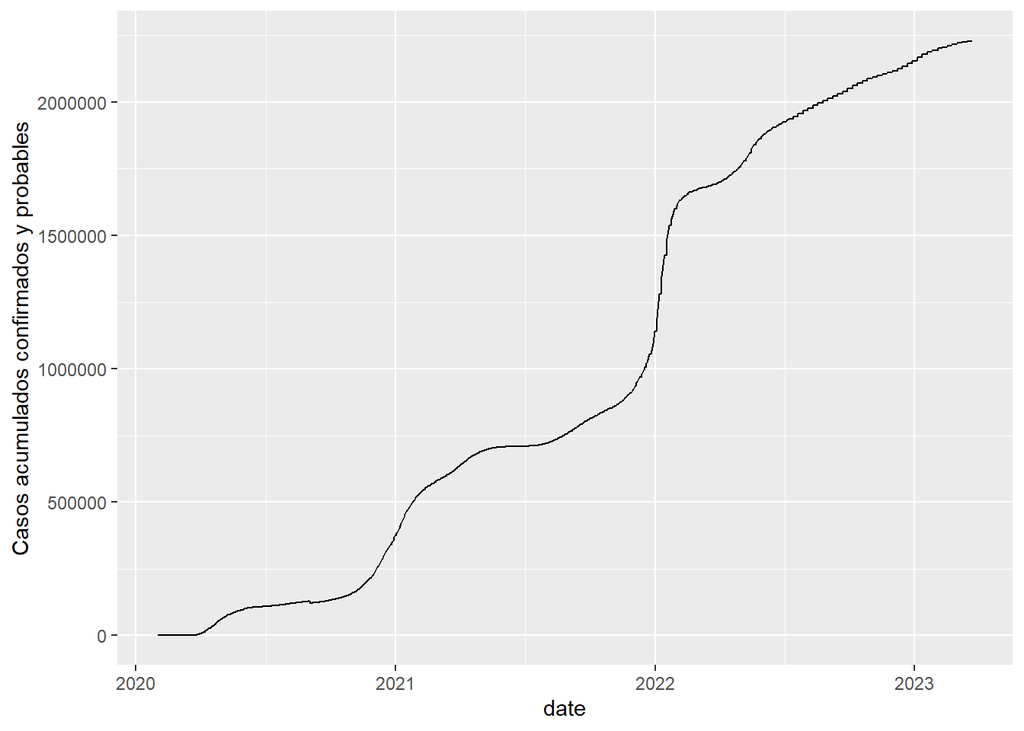

```r
# cargar librerias
library("ggplot2")
library("dplyr")

#--grafico de lineas para visualizar el numero total de casos
covid.estados$date <- as.Date(covid.estados$date)
mass_covid <- covid.estados %>% filter(state=="Massachusetts")

ggplot(data=mass_covid, aes(x=date, y=cases)) +
  geom_line()+
  ylab("Casos acumulados confirmados y probables")
```

El 11 de marzo de 2020, la OMS declaró al Covid-19 pandemia mundial. Agreguemos algunas anotaciones para este evento histórico.

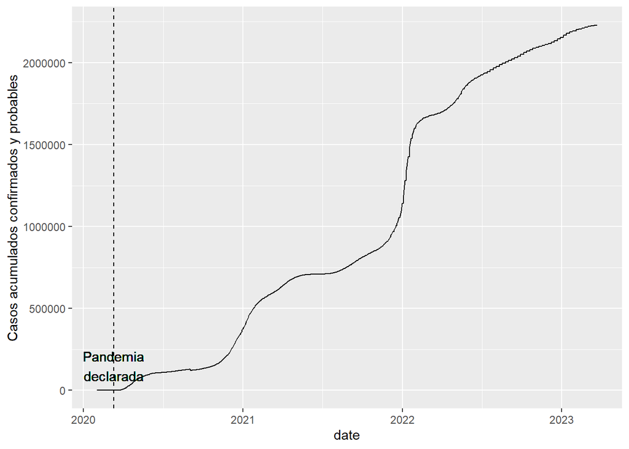

```r
#--agregar anotaciones
ggplot(data=mass_covid, aes(x=date, y=cases))+
  geom_line()+
  ylab("Casos acumulados confirmados y probables")+
  geom_vline(aes(xintercept=as.Date("2020-03-11")), linetype="dashed")+
  geom_text(aes(x=as.Date("2020-03-11"), label="Pandemia\ndeclarada"), y=150000)
```

¿Cuáles estados han sido los más afectados?

```r
#--estados mas afectados
top.estados <- covid.estados%>%
  group_by(state)%>%
  summarise(total_cases = max(cases))%>%
  top_n(5)
top.estados
```

```
## # A tibble: 5 × 2
##   state      total_cases
##   <chr>            <int>
## 1 California    12169158
## 2 Florida        7542869
## 3 Illinois       4107931
## 4 New York       6805271
## 5 Texas          8447168
```

Tracemos los casos confirmados y probables de estos estados a lo largo del tiempo en comparación con Massachusetts.

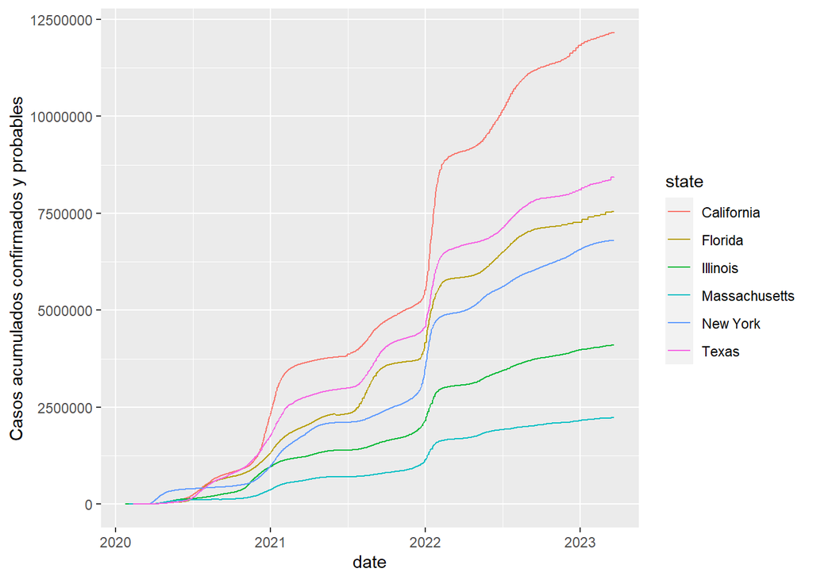

```r
#--comparacion a lo largo del tiempo
top_5 <- covid.estados%>%filter(state %in% c("Massachusetts", "California", "Florida", "Illinois", "New York", "Texas"))

ggplot(data=top_5, aes(x=date, y=cases, color=state)) +
  geom_line()+
  ylab("Casos acumulados confirmados y probables")
```

Si bien la leyenda es útil, a veces es más fácil etiquetar la trama directamente.

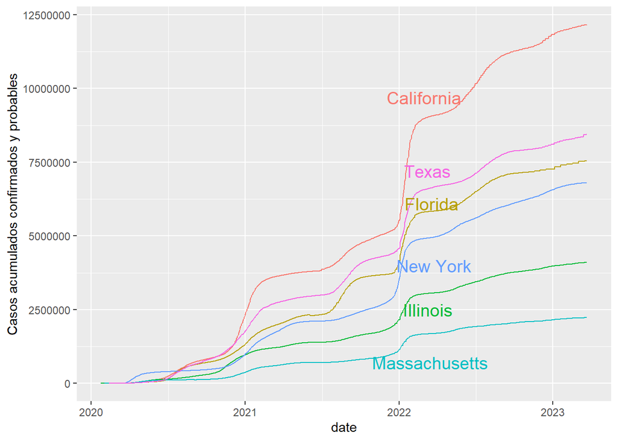

```r
#--etiqueta dentro del grafico
labels <- data.frame(state=c("California", "Texas", "Florida", "New York", "Illinois", "Massachusetts"),
                     x=c(as.Date("2022-03-01"), as.Date("2022-03-10"),
                         as.Date("2022-03-20"), as.Date("2022-03-25"),
                         as.Date("2022-03-10"), as.Date("2022-03-15")),
                     y=c(9700000, 7200000, 6100000, 4000000, 2500000, 700000))
ggplot(data=top_5, aes(x=date, y=cases, color=state))+
  geom_line()+
  theme(legend.position = "none")+
  ylab("Casos acumulados confirmados y probables")+
  geom_text(data=labels, aes(x, y, label=state), size=5)
```

# Sección 5: ¿Por qué es importante la visualización de datos?

### Mirar números brutos es difícil

La mayoría de las personas no quieren investigar los datos por sí mismas. Además, rara vez resulta útil observar los números y las cadenas de caracteres que definen un conjunto de datos. Para convencerse, imprima y mire esta tabla de datos sobre los asesinatos en Estados Unidos desde el paquete dslabs. Cada fila representa un estado con las siguientes variables: nombre, abreviatura, región, población y total de asesinatos.

```r
# cargar librerias de asesinatos
library(tidyverse)
library(dslabs)
data(murders)
head(murders)
```

```
##        state abb region population total
## 1    Alabama  AL  South    4779736   135
## 2     Alaska  AK   West     710231    19
## 3    Arizona  AZ   West    6392017   232
## 4   Arkansas  AR  South    2915918    93
## 5 California  CA   West   37253956  1257
## 6   Colorado  CO   West    5029196    65
```

- ¿Qué es lo que interpretas al mirar esta salida?
- ¿Qué tan rápido puedes determinar qué estados tienen las poblaciones más grandes?
- ¿Qué estados tienen los más pequeños?
- ¿Qué tamaño tiene un estado típico?
- ¿Existe una relación entre el tamaño de la población y el total de asesinatos?
- ¿Cómo varían las tasas de homicidio entre las regiones del país?

### Mirar una gráfico es más informativo

¡Para la mayoría de las personas, buscar tendencias en los cuadros es difícil! Es bastante difícil extraer esta información simplemente mirando los números.

Nos recuerda el dicho “una imagen vale más que mil palabras”. La visualización de datos proporciona una forma poderosa de comunicar un hallazgo basado en datos. En algunos casos, la visualización es tan convincente que no es necesario realizar ningún análisis posterior. La gente confía en lo que ve. También observamos que muchas herramientas de análisis de datos ampliamente utilizadas fueron iniciadas por descubrimientos realizados mediante análisis de datos exploratorios. Es quizás la parte más importante del análisis de datos, pero a menudo se pasa por alto.

# Sección 6: Principios de visualización de datos

Aquí pretendemos proporcionar algunos principios generales que se pueden utilizar como guía para una visualización de datos eficaz. Mostraremos algunos ejemplos de estilos de gráficos que debemos evitar, explicaremos cómo mejorarlos y los utilizaremos como motivación para una lista de principios. Compararemos y contrastaremos los gráficos que siguen estos principios con los que no.

Los principios se basan principalmente en investigaciones relacionadas de cómo los humanos detectan patrones y hacen comparaciones visuales. Los enfoques preferidos son aquellos que mejor se adaptan a la forma en que nuestro cerebro procesa la información visual.

Al decidir un enfoque de visualización, también es importante tener en cuenta nuestro objetivo. Nuestro objetivo debe guiar qué tipo de visualización crea. Nuestros objetivos pueden variar y es posible que estemos comparando un número visible de cantidades, describiendo una distribución para categorías o valores numéricos, comparando los datos de dos grupos o describiendo la relación entre dos variables.

Siempre debemos presentar los datos de forma veraz. Las mejores visualizaciones son veraces, intuitivas y estéticamente agradables.

### PRINCIPIO 1: CODIFICAR LOS DATOS MEDIANTE SEÑALES VISUALES

Comenzamos describiendo algunos principios para codificar datos. Hay varios enfoques a nuestra disposición, incluyendo posición, longitudes alineadas, angulos, áreas, brillo y tono de color.

#### Uso del navegador de Internet

Veamos algunos ejemplos:

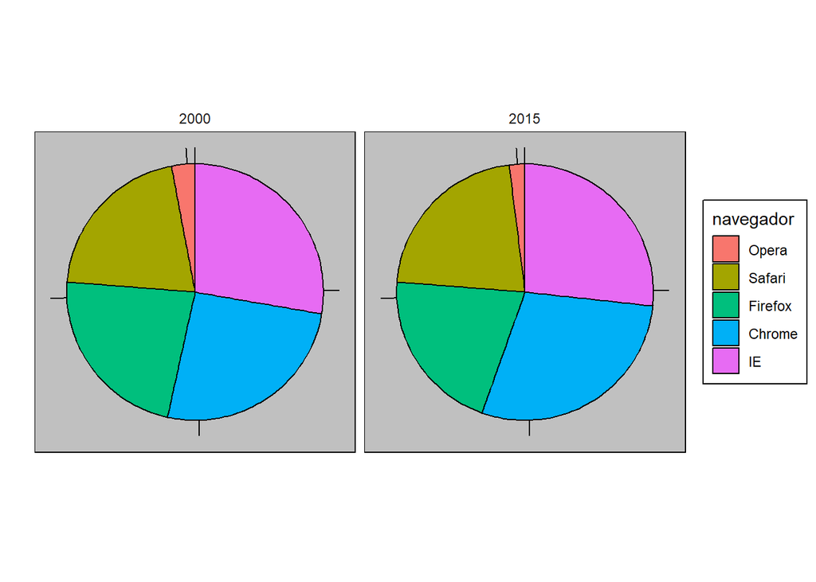

```r
#--principio 1: codificar los datos mediante señales visuales
library(ggplot2)
library(dplyr)
library(tidyverse)
library(gridExtra)
library(dslabs)
#--preferencias de uso de navegador
ds_theme_set() # permite especificar un tema o estilo a los datos
browsers <- data.frame(navegador = rep(c("Opera", "Safari", "Firefox", "IE", "Chrome"), 2),
año = rep(c(2000, 2015), each = 5),
porcentaje = c(3, 21, 23, 28, 26, 2, 22, 21, 27,29)) %>%
  mutate(navegador = reorder(navegador, porcentaje))

library(ggthemes)
#--grafico polar o grafico circular
p1 <- browsers %>% ggplot(aes(x = "", y = porcentaje, fill = navegador)) +
  geom_bar(width = 1, stat = "identity", col = "black") + coord_polar(theta = "y") +
  theme_excel() + xlab("") + ylab("") +
  theme(axis.text=element_blank(),
        axis.ticks = element_blank(),
        panel.grid = element_blank()) +
  facet_grid(.~año) # mostrar el grafico en dos paneles por año
p1
```

Esta es una representación gráfica de porcentajes ampliamente utilizada llamada gráfico circular. Es muy popular en Microsoft Excel. El objetivo de este gráfico circular es informar los resultados de dos encuestas hipotéticas sobre las preferencias de navegador realizadas en 2000 y luego en 2015 utilizando porcentajes.

Aquí representamos cantidades con áreas y ángulos, ya que tanto el ángulo como el área de cada porción de pastel son proporcionales a la cantidad que representa. Esta resulta ser una elección subóptima ya que, como lo demuestran los estudios de percepción, los humanos no son buenos para cuantificar ángulos con precisión y son aún peores cuando solo hay área disponible.

Es difícil cuantificar los ángulos y determinar cómo cambiaron los porcentajes en los gráficos anteriores de 2000 a 2015. ¿Puedes determinar los porcentajes reales y clasificar la popularidad de los navegadores? ¿Puedes ver cómo cambiaron los porcentajes de 2000 a 2015? No es fácil distinguirlo en el gráfico.

Los gráficos circulares son una muy mala forma de mostrar información. El ojo es bueno para juzgar medidas lineales y malo para juzgar áreas relativas. Un gráfico de barras es una forma preferible de mostrar este tipo de datos.

La forma preferida de graficar cantidades es utilizar longitud y posición ya que los humanos son mucho mejores juzgando medidas lineales. El diagrama de barras utiliza barras de longitud proporcional a las cantidades de interés. Al agregar líneas horizontales en valores estratégicamente elegidos, en este caso en cada múltiplo de 10, facilitamos la cuantificación a través de la posición de la parte superior de las barras.

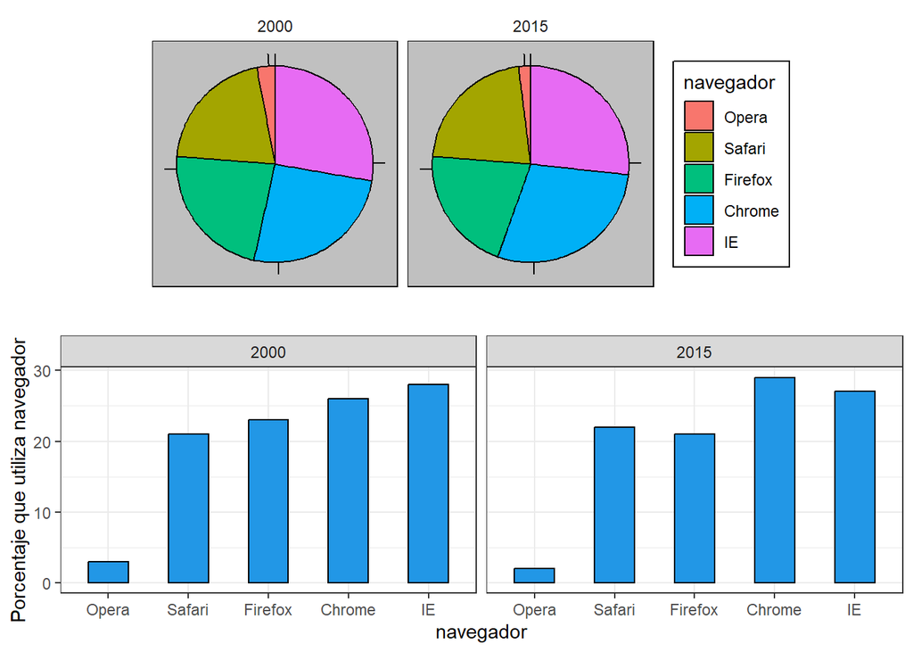

```r
#--graficos de barras
p2 <- browsers %>%
  ggplot(aes(navegador, porcentaje)) +
  geom_bar(stat = "identity", width=0.5, fill=4, col =1) +
  ylab("Porcentaje que utiliza navegador") +
  facet_grid(.~año)
grid.arrange(p1, p2, nrow =2) # unir los graficos
```

En general, la posición y la longitud son las formas preferidas de mostrar cantidades en lugar de ángulos, éstos son preferidos para áreas.

### PRINCIPIO 2: NO SE DEBE DISTORSIONAR LAS CANTIDADES

#### Detenciones en la frontera suroeste

A continuación se muestra un ejemplo ilustrativo de más diagramas de barras. El objetivo es mostrar el número de detenciones en la frontera suroeste en 3 años consecutivos.

Cuando se utilizan diagramas de barras, es deshonesto no comenzar las barras en 0. Esto se debe a que, al usar un diagrama de barras, estamos dando a entender que la longitud es proporcional a las cantidades que se muestran. Al evitar 0, se pueden hacer que diferencias relativamente pequeñas parezcan mucho mayores de lo que realmente son. Este enfoque lo utilizan a menudo políticos u organizaciones de medios que intentan exagerar una diferencia.

**No se debe distorsionar las cantidades.**

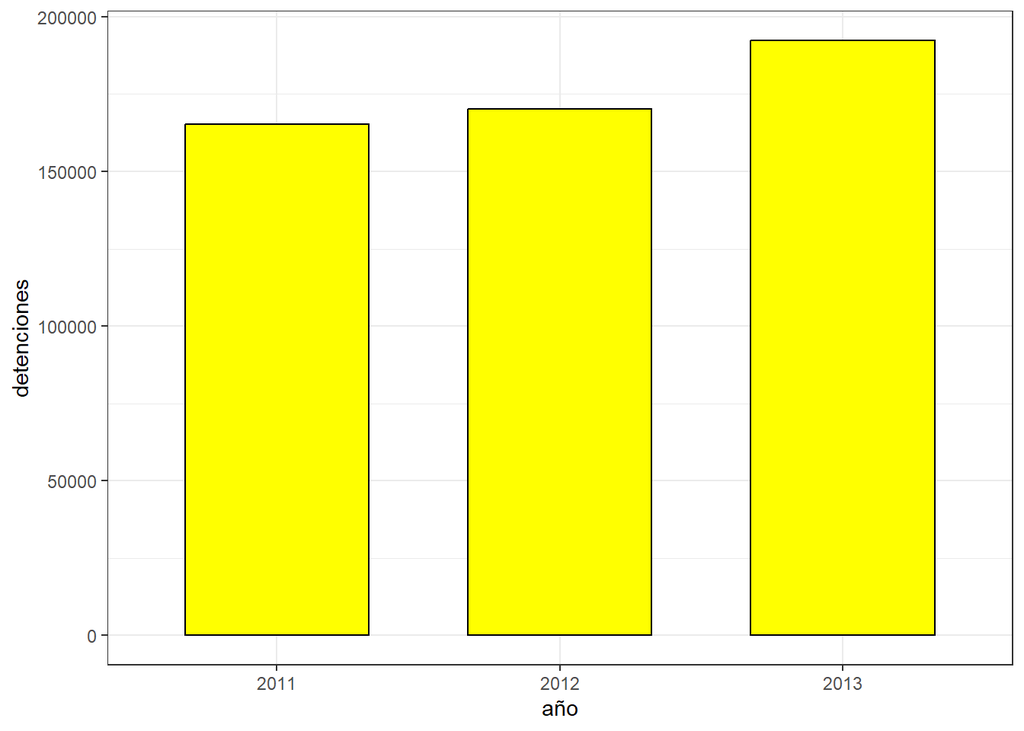

```r
#--principio 2:no distorsionar las cantidades
data.frame(año = as.character(c(2011, 2012, 2013)),detenciones = c(165244, 170223, 192298)) %>%
  ggplot(aes(año, detenciones)) +
  geom_bar(stat = "identity", fill = "yellow", col = "black", width = 0.65)
```

#### Tasa de asesinatos

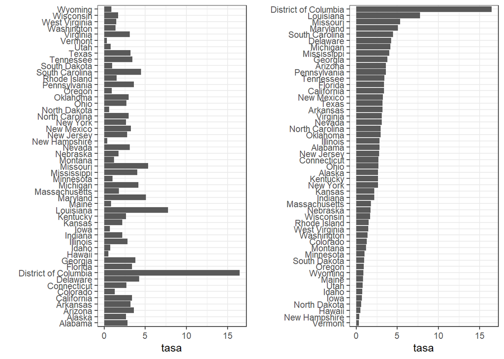

```r
#--ordenar por valores que por orden alfabetico
data(murders)
p1 <- murders %>% mutate(tasa = total / population * 100000) %>%
  ggplot(aes(state, tasa)) +
  geom_bar(stat="identity") +
  coord_flip() +
  xlab("")
p2 <- murders %>% mutate(tasa = total / population *100000) %>%
  mutate(state = reorder(state, tasa)) %>%
  ggplot(aes(state, tasa)) +
  geom_bar(stat="identity") +
  coord_flip() +
  xlab("")
grid.arrange(p1, p2, ncol = 2)
```

Aquí hay más diagramas de barras. El objetivo es mostrar las tasas de asesinatos estatales por estado. Como podemos ver, puedes ordenar los gráficos de forma diferente, como alfabética o numéricamente. Raramente queremos usar el orden alfabético. En lugar de eso deberíamos ordenar por un valor significativo. Si nuestro objetivo es comparar las tasas de homicidio entre estados, probablemente estemos interesados en los estados más peligrosos y seguros. Tiene más sentido ordenar por la tasa actual que por orden alfabético.

**Muertes por armas de fuego en Florida**

[figure not shown]

Aquí hay un gráfico lineal de muertes por armas de fuego en Florida a lo largo del tiempo.

El objetivo es mostrar el aumento de los asesinatos por arma de fuego después de que se promulgara la ley “Defiende tu posición” en 2005.

Sin embargo, observe que el eje y está invertido y, si no presta mucha atención, podría sacar la conclusión errónea de que el número de asesinatos ha disminuido debido a la ley.

**Haz que tus ejes sean intuitivos.**

Voltear el eje y hace que el gráfico sea menos engañoso e ilustra claramente el aumento:

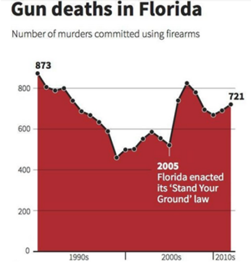

### PRINCIPIO 3: MOSTRAR LOS DATOS

**Altura promedio**

Nos hemos centrado en mostrar cantidades únicas en todas las categorías. Ahora centramos nuestra atención en mostrar datos, centrándonos en comparar grupos.

Nuestro siguiente gráfico incluye un diagrama de barras donde el objetivo es comparar la altura entre mujeres y hombres. Un gráfico comúnmente utilizado para comparaciones entre grupos, popularizado por software como Microsoft Excel, muestra los promedios y el error estándar.

El gráfico se ve así:

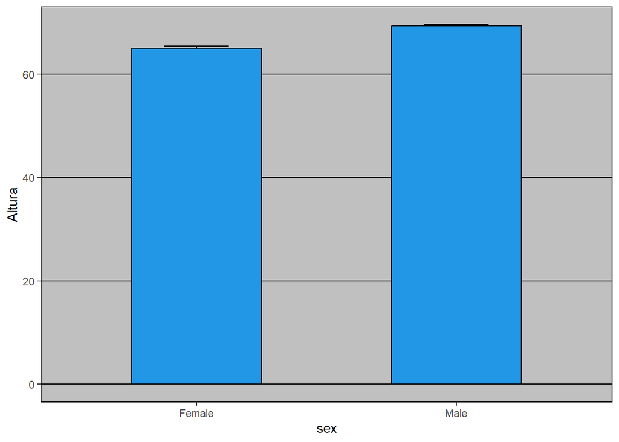

```r
#--principio 3: mostrar los datos

#--comparar grupos: grafico de barras de alturas promedios
data(heights)
p1 <- heights %>% group_by(sex) %>%
  summarize(promedio = mean(height), ee=sd(height)/sqrt(n())) %>%
  ggplot(aes(sex, promedio)) + theme_excel() +
  geom_errorbar(aes(ymin = promedio - 2*ee, ymax = promedio+2*ee), width = 0.25)+
  geom_bar(stat = "identity", width= 0.5, fill= 4, col = 1) +
  ylab("Altura"
  )
p1
```

El promedio de cada grupo está representado por la parte superior de cada barra y los brazos se expanden hasta el promedio más dos errores estándar. Si todo lo que alguien recibe es este gráfico, tendrá poca información sobre qué esperar si se encuentra con un grupo de hombres y mujeres. Las barras empiezan en 0, ¿significa esto que hay personas diminutas? ¿Son todos los hombres más altos que las mujeres más altas? ¿Hay un rango de alturas? No se puede responder estas preguntas ya que no hemos proporcionado información sobre la distribución de la altura.

Esto nos lleva a nuestro siguiente principio: **mostrar los datos.**

Este código simple de ggplot ya genera un gráfico más informativo que el diagrama de barras simplemente mostrando todos los puntos de datos:

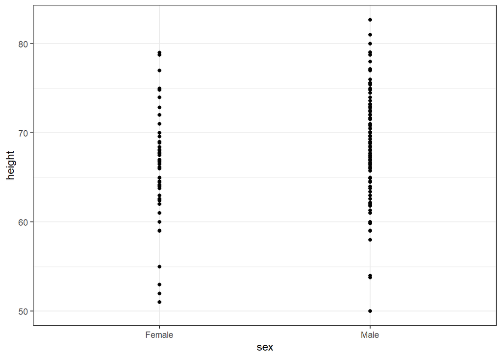

```r
#--mostrar los datos
heights %>%
  ggplot(aes(sex, height)) + geom_point()
```

Por ejemplo, tenemos una idea del rango de datos. Sin embargo, este gráfico también tiene limitaciones, ya que en realidad no podemos ver todos los puntos (238 y 812 puntos para mujeres y hombres respectivamente), y muchos puntos están trazados uno encima del otro. Como hemos descrito, visualizar la distribución es mucho más informativo.

Lo primero es agregar jitter: agregando un pequeño cambio aleatorio a cada punto. En este caso, añadir un jitter horizontal no altera la interpretación, ya que la altura de los puntos no cambia, pero minimizamos el número de puntos que caen unos encima de otros y por tanto tenemos una mejor idea de cómo se distribuyen los datos.

Una segunda mejora proviene del uso de alfa bleding: hacer que los puntos sean algo transparentes. Cuantos más puntos caigan unos encima de otros, más oscura será la trama, lo que también nos ayuda a tener una idea de cómo se distribuyen los puntos.

Aquí está el mismo gráfico con jitter y alfa blending:

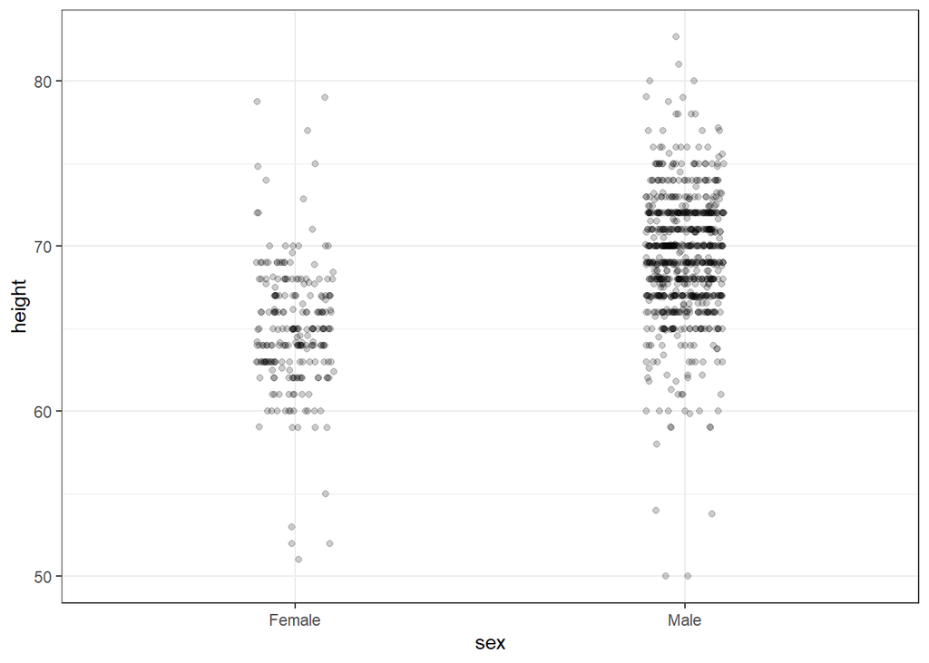

```r
#--jitter y alfa blending
heights %>% ggplot(aes(sex, height)) +
  geom_jitter(width = 0.1, alpha = 0.2)
```

Ahora empezamos a tener la sensación de que, en promedio, los hombres son más altos que las mujeres. También observamos líneas horizontales oscuras que demuestran que muchos valores informados están redondeados al número entero más cercano. Dado que hay tantos puntos, es más eficaz mostrar distribuciones que mostrar puntos individuales. En nuestro siguiente ejemplo mostramos las mejoras proporcionadas por las distribuciones y sugerimos principios adicionales.

#### Distribuciones de altura

Anteriormente vimos este gráfico utilizado para comparar las alturas de hombres y mujeres. Sin embargo, ¿qué pasa si tenemos demasiados puntos? Dado que hay tantos puntos, es más eficaz mostrar distribuciones que mostrar puntos individuales. Por ello mostramos histogramas para cada grupo, con el objetivo de mostrar la distribución de alturas entre mujeres y hombres:

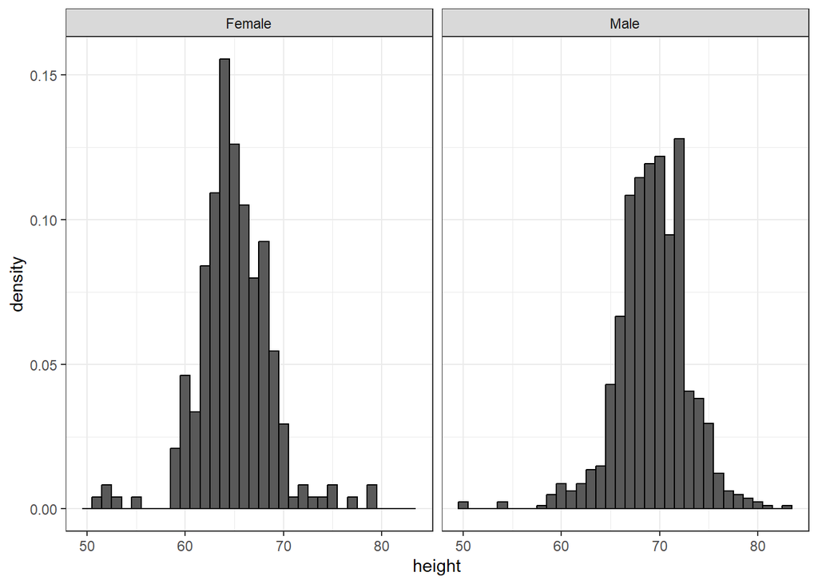

```r
#--principio 4: mantener los ejes iguales para comparar datos

#--histograma para la distribucion de altura
heights %>%
  ggplot(aes(height, ..density..)) +
  geom_histogram(binwidth = 1, color="black") +
  facet_grid(.~sex) # mostrar dos paneles para cada nivel de sexo, uno al lado del otro
```

A partir de este gráfico, resulta inmediatamente obvio que los hombres son, en promedio, más altos que las mujeres. Un principio importante aquí es **mantener los ejes iguales al comparar datos en dos gráficos.** Facilite las comparaciones mediante el uso de ejes comunes.

**Alinee los gráficos verticalmente para ver los cambios horizontales y horizontalmente para ver los cambios verticales**

En estos histogramas, la indicación visual relacionada con disminuciones o aumentos de altura son desplazamientos hacia la izquierda o hacia la derecha respectivamente: cambios horizontales. Alinear los gráficos verticalmente nos ayuda a ver este cambio cuando los ejes están fijos:

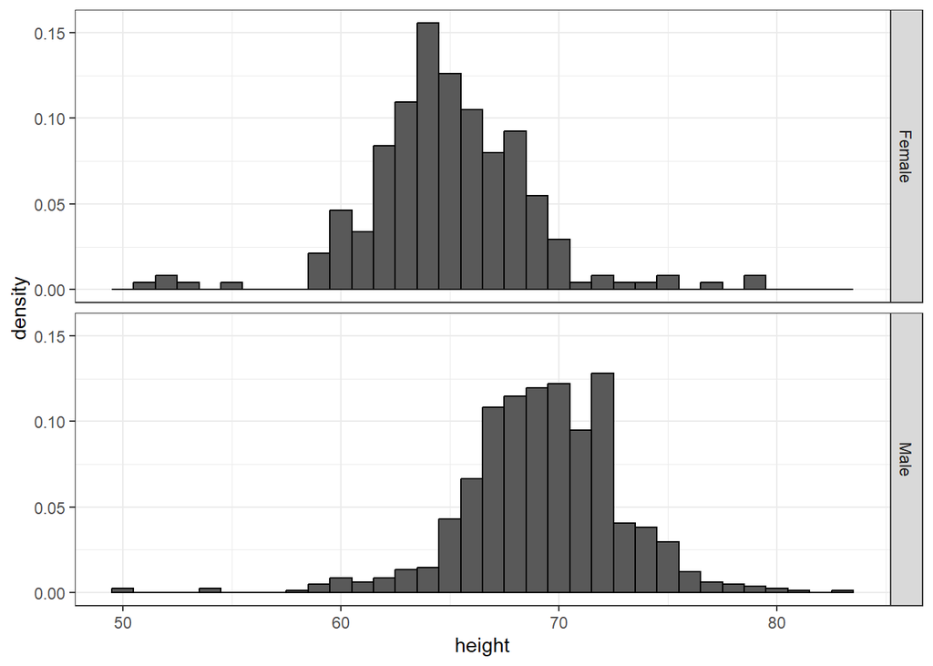

```r
#--graficos verticales para ver cambios horizontales
p2 <- heights %>%
  ggplot(aes(height, ..density..)) +
  geom_histogram(binwidth = 1, color="black") +
  facet_grid(sex~.) # mostrar dos paneles para cada nivel de sexo, uno encima del otro
p2
```

Este gráfico hace que sea mucho más fácil notar que los hombres son, en promedio, más altos. Si en lugar de histogramas queremos el resumen más compacto proporcionado por los diagramas de caja, entonces los alinearemos horizontalmente, ya que, de forma predeterminada, los diagramas de caja se mueven hacia arriba y hacia abajo con los cambios de altura.

#### Ingresos de países

Para el siguiente principio principio, observamos un diagrama de caja que compara los ingresos de los países entre años en cada continente.

Al comparar los datos de ingresos entre 1972 y 2002 en toda la región, obtuvimos una figura similar a la siguiente.

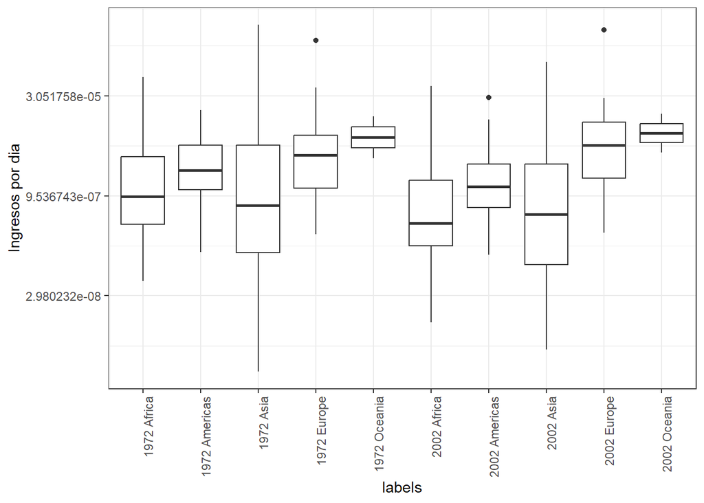

```r
#--principio 5: facilita las comparaciones

#--visualizar los ingresos per capita y los continentes en los años 1972 y 2002
library(gapminder)
data(gapminder)
gapminder %>%
  filter(year %in% c(1972, 2002) & !is.na(gdpPercap)) %>%
  mutate(dolar_por_dia = gdpPercap/pop/365) %>%
  mutate(labels = paste(year, continent)) %>%
  ggplot(aes(labels, dolar_por_dia)) +
  geom_boxplot() +
  theme(axis.text.x = element_text(angle = 90, hjust = 1)) +
  scale_y_continuous(trans = "log2") +
  ylab("Ingresos por dia")
```

Tenga en cuenta que, para cada continente, queremos comparar las distribuciones de 1972 con 2002. La opción predeterminada ordena alfabéticamente de modo que las etiquetas con 1972 aparezcan antes de las etiquetas con 2002, lo que dificulta las comparaciones.

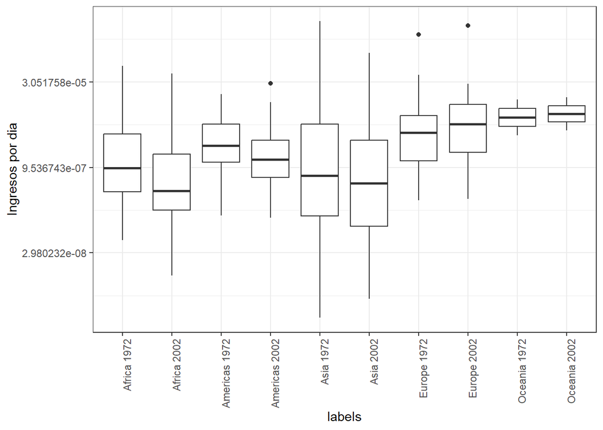

```r
#--ordenar comparaciones de 1972 y 2002
gapminder %>%
  filter(year %in% c(1972, 2002) & !is.na(gdpPercap)) %>%
  mutate(dolar_por_dia = gdpPercap/pop/365) %>%
  mutate(labels = paste(continent, year)) %>%
  ggplot(aes(labels, dolar_por_dia)) +
  geom_boxplot() +
  theme(axis.text.x = element_text(angle = 90, hjust = 1)) +
  scale_y_continuous(trans = "log2") +
  ylab("Ingresos por dia")
```

La comparación es aún más fácil cuando se utiliza el color para indicar las dos cosas comparadas. **Facilite la comparación utilizando colores.**

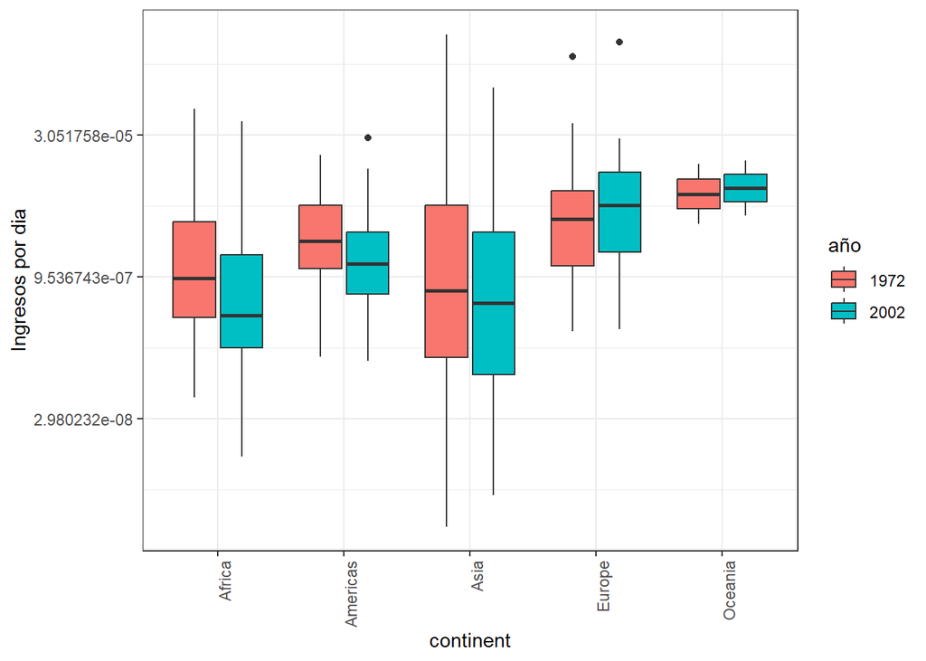

```r
#--utilizar colores
gapminder %>%
  filter(year %in% c(1972, 2002) & !is.na(gdpPercap)) %>%
  mutate(dolar_por_dia = gdpPercap/pop/365, año = factor(year)) %>%
  ggplot(aes(continent, dolar_por_dia, fill = año)) +
  geom_boxplot() +
  theme(axis.text.x = element_text(angle = 90, hjust = 1)) +
  scale_y_continuous(trans ="log2") +
  ylab("Ingresos por dia")
```

#### Utilice etiquetas en lugar de leyendas

Para los gráficos de tendencias, recomendamos etiquetar las líneas en lugar de utilizar leyendas, ya que el espectador puede ver rápidamente qué línea corresponde a cada país. En realidad, esta sugerencia se aplica a la mayoría de los gráficos: **Generalmente se prefiere el etiquetado a las leyendas.**

Demostramos cómo podemos hacer esto utilizando los datos de esperanza de vida. Definimos una tabla de datos con las ubicaciones de las etiquetas y luego usamos un segundo mapeo solo para estas etiquetas:

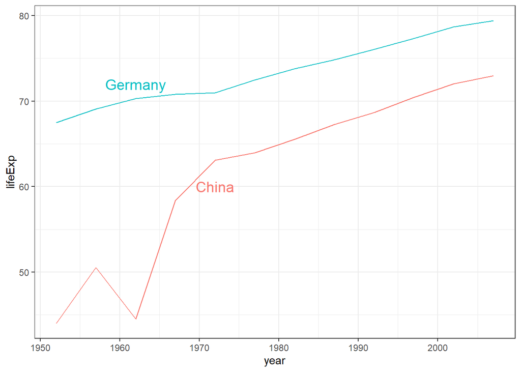

```r
#--principio 6: utiliza etiquetas en lugar de leyendas

paises <- c("China","Germany")
labels <- data.frame(country = paises, x = c(1972, 1962), y = c(60, 72))
gapminder %>%
  filter(country %in% paises) %>%
         ggplot(aes(year, lifeExp, col = country)) +
           geom_line() +
           geom_text(data = labels, aes(x, y, label = paises), size = 5) +
           theme(legend.position = "none")
```

## Principales conclusiones

- Utilice posición y longitud, en lugar de ángulos o áreas.
- En general, no utilice gráficos circulares.
- No distorsionar las cantidades.
- Ordenar categorías de forma significativa.
- Haz que los ejes sean intuitivos.
- Mostrar los datos.
- Mantenga los ejes iguales.
- Facilita las comparaciones.
- Utilice etiquetas en lugar de leyendas.
- Piensa en los daltónicos.

# Sección 7: Opciones de visualización de datos

Hay muchas técnicas de visualización que puede utilizar y muchas opciones disponibles en el

paquete ggplot2. Visitar: https://exts.ggplot2.tidyverse.org/gallery/

Si bien cubrimos algunos aquí y los revisamos a continuación, debido a limitaciones de tiempo y espacio, no podremos cubrirlos todos. Un recurso útil si está tratando de decidir cuál es la visualización de datos adecuada para sus datos es la siguiente pagina: [https://www.data-to-viz.com](https://www.data-to-viz.com/#boxplot)

## Scatter plot o gráfico de dispersion

```r
#--SECCION 7: OPCIONES DE VISUALIZACION DE DATOS


head(murders)
```

```
##        state abb region population total
## 1    Alabama  AL  South    4779736   135
## 2     Alaska  AK   West     710231    19
## 3    Arizona  AZ   West    6392017   232
## 4   Arkansas  AR  South    2915918    93
## 5 California  CA   West   37253956  1257
## 6   Colorado  CO   West    5029196    65
```

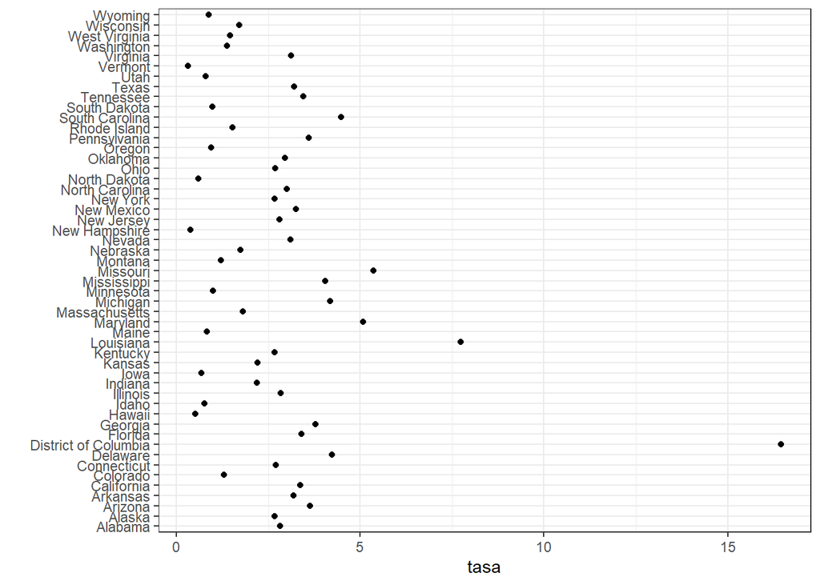

```r
#--scatter plot o grafico de dispersion
murders %>% mutate(tasa = total / population * 100000) %>%
  ggplot(aes(state, tasa)) +
  geom_point() +
  coord_flip() +
  xlab("")
```

Un diagrama de dispersión permite la comparación a lo largo de una escala común. Sin embargo, el orden debe ser significativo.

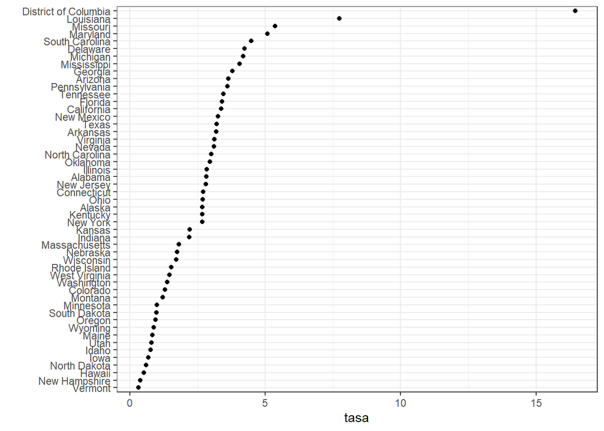

```r
#--ordenar por tasa
murders %>% mutate(tasa = total / population * 100000) %>%
  mutate(state=reorder(state, tasa)) %>%
  ggplot(aes(state, tasa)) +
  geom_point() +
  coord_flip() +
  xlab("")
```

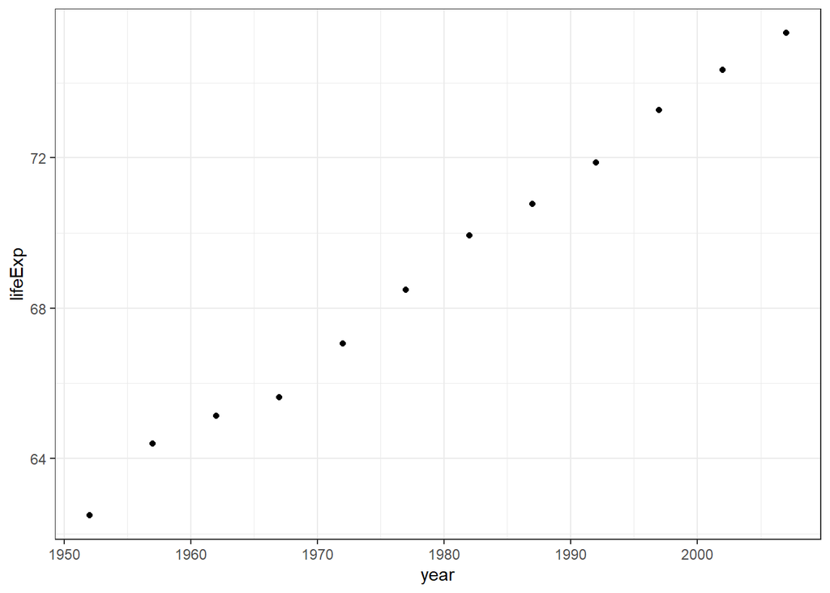

```r
#--histogramas

#--Graficos de cajas

#--grafico de barras

#--grafico de puntos
library(gapminder)
data(gapminder)
gapminder %>%
  filter(country == "Argentina") %>%
  ggplot(aes(year, lifeExp)) +
  geom_point()
```

## Grafico de líneas

Un gráfico de líneas es útil para mostrar tendencias o cómo cambian los datos con el tiempo. Los gráficos de líneas se utilizan para datos cuantitativos durante un intervalo o período de tiempo continuo, donde el eje x suele ser una escala de tiempo.

Por ejemplo, es posible que desee observar una tendencia a lo largo del tiempo mediante el uso de gráficos de series de tiempo con el tiempo en el eje x y el resultado o medición de interés en el eje y.

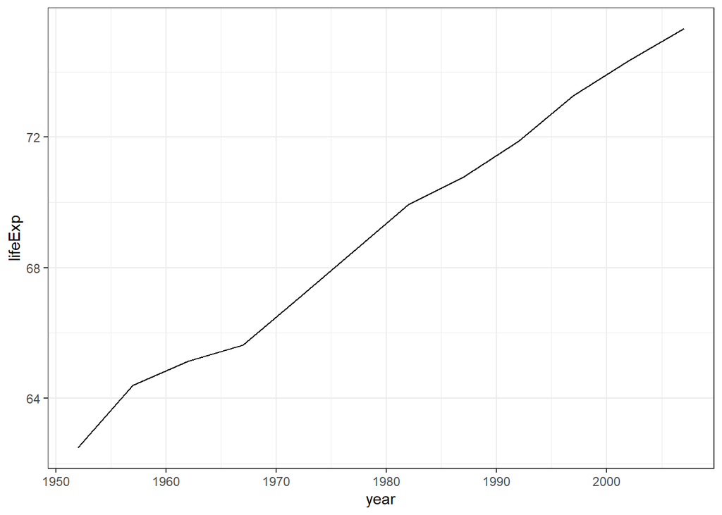

```r
#--funcion geom_line
gapminder %>%
  filter(country == "Argentina"
  ) %>%
  ggplot(aes(year, lifeExp)) +
  geom_line()
```

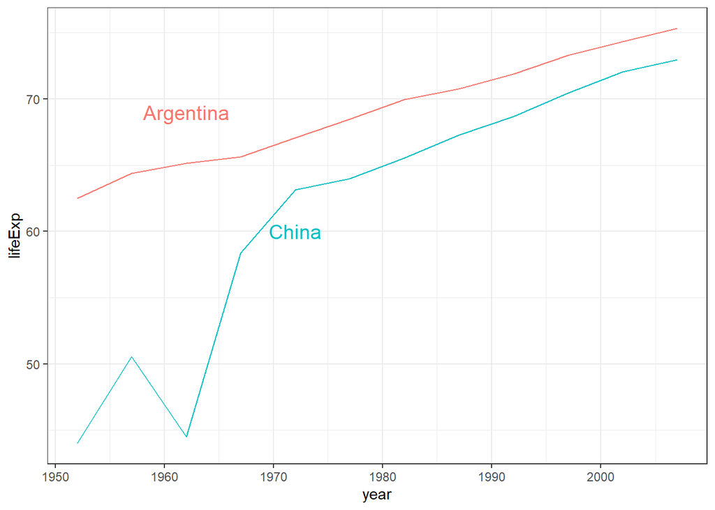

```r
#--comparar dos paises
paises <- c("China", "Argentina")
labels <- data.frame(country = paises, x = c(1972, 1962), y = c(60, 69))
gapminder %>%
  filter(country %in% paises) %>%
  ggplot(aes(year, lifeExp, col = country)) +
  geom_line() +
  geom_text(data = labels, aes(x, y, label = paises), size = 5) +
  theme(legend.position = "none")
```

## Mapas de calor

A veces, es posible que desee utilizar diferentes magnitudes de color, como variaciones de tono o intensidad, para mostrar grupos o cómo cambian las variables en un espacio. **Utilice los colores como señal visual.**

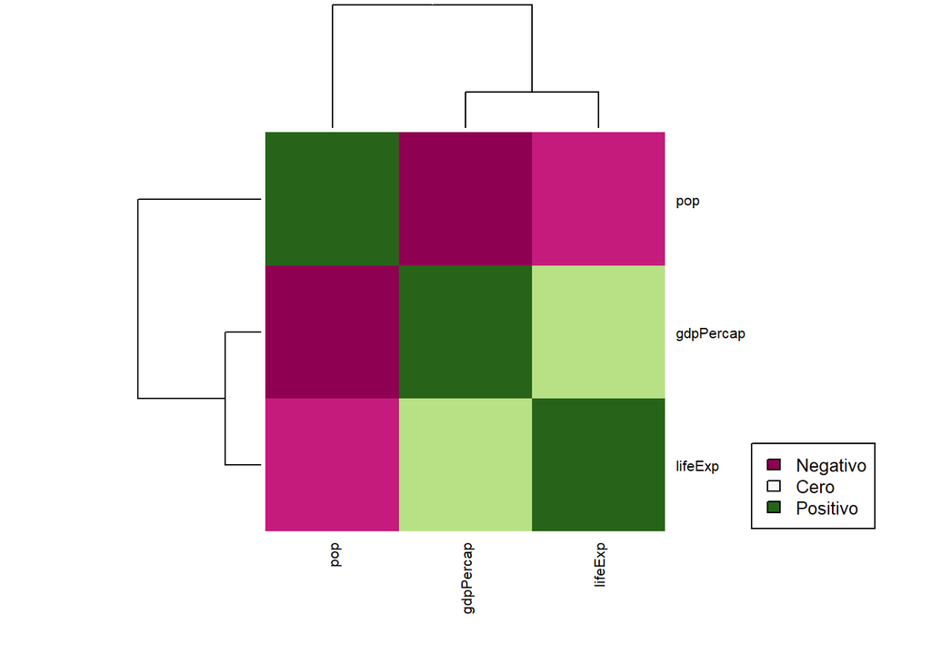

```r
#--mapa de calor
library(RColorBrewer)
datos.mundo <- filter(gapminder, year%in%c(2007))
mundo.datos.numericos <- datos.mundo %>% select(lifeExp, pop, gdpPercap)
mundo.cor <- cor(mundo.datos.numericos, use = "pairwise.complete.obs")
heatmap(x = mundo.cor, col = brewer.pal(11, "PiYG"),
margins = c(6, 6), symm = TRUE,
cexRow = 0.8,
cexCol = 0.8)
legend(x= "bottomright", xpd=TRUE,
       legend=c("Negativo", "Cero", "Positivo"), cex=  0.8,
       fill=colorRampPalette(brewer.pal(11, "PiYG"))(3))
```

# Seccion 8: Mapeo

Para la visualización de datos geográficos con datos geoespaciales, es posible que desee realizar algunos mapas. sf es un paquete que involucran clases u objetos espaciales. El paquete ggplot2 toma sf objetos. Un recurso para mapas es el paquete rnaturalearth, que proporciona un mapa de países de todo el mundo.

```r
#--mapa del mundo
library(ggplot2)
theme_set(theme_bw())
library(sf)
library(rnaturalearth)
library(rnaturalearthdata)
mundo<- ne_countries(scale = "medium", returnclass = "sf")
class(mundo)
```

```
## [1] "sf"         "data.frame"
```

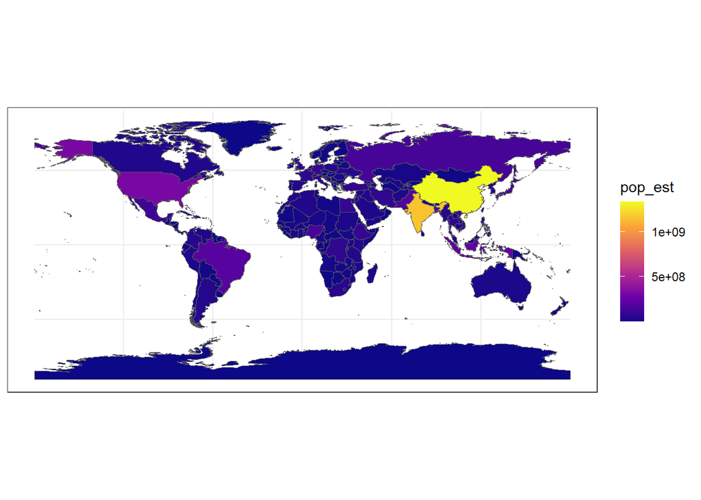

```r
ggplot(data = mundo) +
  geom_sf(aes(fill = pop_est)) +
  scale_fill_viridis_c(option = "plasma") # color plasma
```

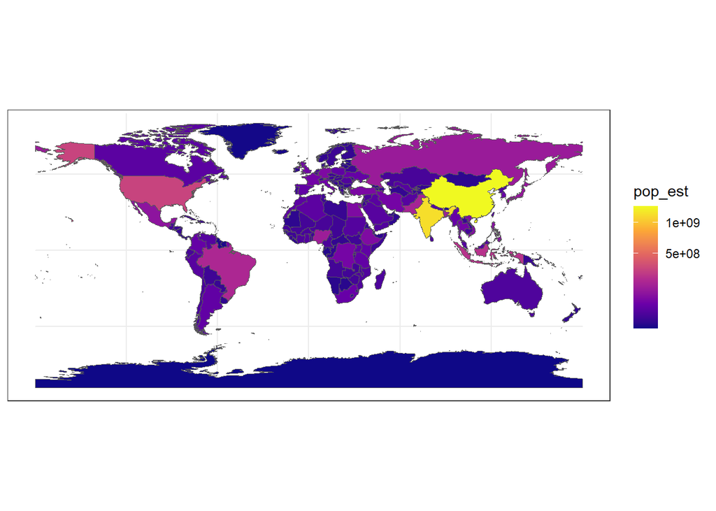

```r
#-- aplicar transformacion de la variable
ggplot(data = mundo) +
  geom_sf(aes(fill = pop_est)) +
  scale_fill_viridis_c(option = "plasma", trans = "sqrt") # transformacion raiz cuadrada
```

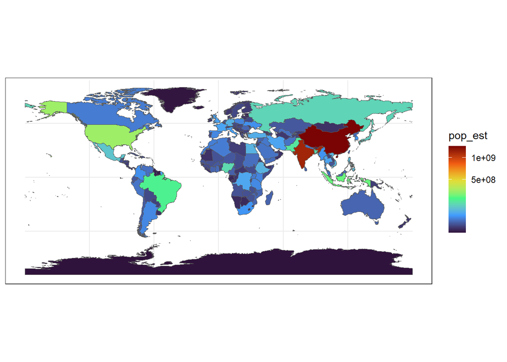

```r
#-- cambiar color
ggplot(data = mundo) +
  geom_sf(aes(fill = pop_est)) +
  scale_fill_viridis_c(option = "turbo", trans = "sqrt")
```

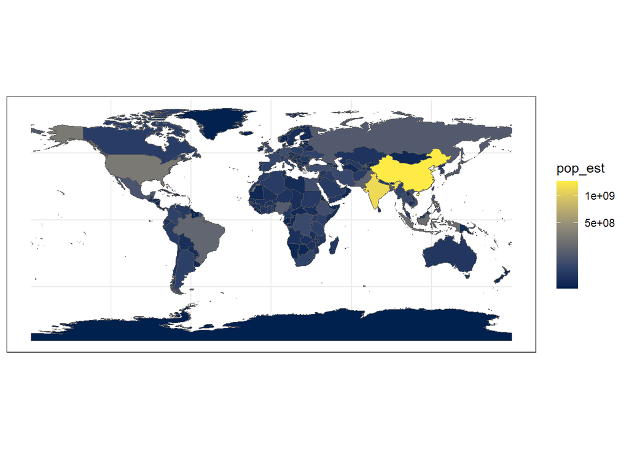

```r
#-- cambiar colores
ggplot(data = mundo) +
  geom_sf(aes(fill = pop_est)) +
  scale_fill_viridis_c(option = "cividis", trans = "sqrt")
```